# AP-4209 ESIEE-Paris: 2023 -2024

Fouille de données avec R pour la data science et l’intelligence artificielle

Projet 1 : Classification bayésienne

Eliott Vigier et Alexandre Wu – ESIEE Paris

**Résumé :** Nous développerons un projet de classification bayésienne en utilisant l’ensemble de données sur les émotions (Kaggle) en plusieurs étapes. Nous allons employer une série de pré-traitement plus complexes et éventuellement étendre l’approche bayésienne pour inclure des ajustements (tuning) ou des probabilité supplémentaires.

**Objectif principal :** Développer un classificateur bayésien pour prédire les émotions à partir de données textuelles.

**Source des données :** Jeu de données sur les émotions.

- **Lien :** Emotion Dataset (kaggle.com)

### 1 Introduction

Ce travail se concentre sur la mise en œuvre d’une classification bayésienne pour analyser et prédire les émotions à partir de données textuelles, en utilisant un jeu de données spécifique disponible sur Kaggle. L’objectif est de développer un classificateur capable de distinguer différentes émotions en appliquant des techniques avancées de traitement du langage naturel (NLP), telles que la tokenisation, la stemmatisation ou la lemmatisation, et la vectorisation TF-IDF. Ce processus comprend plusieurs étapes clés, allant de la préparation et le nettoyage des données à l’entraînement et l’évaluation du modèle, avec une attention particulière sur l’exactitude, la précision, le rappel, et le score F1. Le projet vise également à explorer des améliorations potentielles et des ajustements pour optimiser la performance du classificateur bayésien.

#### 1.1 Programmation

Nous utilisons :

- `dplyr`: Manipulation et filtrage des données avec des fonctions intuitives. Essentiel pour le nettoyage et la préparation des données.
- `kableExtra`: Amélioration des tableaux en HTML ou PDF pour une présentation esthétique des données. [Génération de tableaux améliorés](https://cran.r-project.org/web/packages/kableExtra/vignettes/awesome_table_in_html.html).
- `tm`: Outils pour le nettoyage et la préparation de textes, cruciaux pour l’analyse de contenu textuel.
- `knitr`: Intégration de code R dans des documents LaTeX, HTML, Markdown pour la reproduction des analyses.
- `tokenizers`: Facilitation de la tokenisation et stemming de textes, une étape préliminaire importante dans le prétraitement des données textuelles.
- `tidytext`: Application des principes du tidyverse au traitement de texte, simplifiant le travail avec des données textuelles.
- `ggplot2`, `RColorBrewer`, `wordcloud`: Utilisés pour la visualisation de données, permettant la création de graphiques avancés, de palettes de couleurs personnalisées et de nuages de mots.
- `e1071`, `caret`: Fourniture de fonctions pour l’apprentissage statistique, incluant la classification bayésienne, facilitant la création de modèles prédictifs et la validation croisée.

### 2 Chargement et exploration des données

##### 2.1 Chargez le jeu de données dans R

On commence à charger les librairies nécessaires pour le projet :

```r
library(dplyr)
library(kableExtra)
library(tm)
library(knitr)
library(tokenizers)
library(tidytext)
```

```r
library(ggplot2)
library(RColorBrewer)
library(wordcloud)
library(e1071)
library(caret)
```

Ensuite on charge le dataset :

```r
# Chargement du jeu de donnée
df <- read.csv("Emotion_classify_Data.csv")
```

Affichage du tableau avec *kableExtra*

```r
df %>%
  kbl(digits=3) %>%
  kable_styling(bootstrap_options = "striped", full_width = F, position = "center", latex_options = 'stripped') %>% scroll_box( height = "250px")
```

| Comment | Emotion |
| --- | --- |
| i seriously hate one subject to death but now i feel reluctant to drop it | fear |
| im so full of life i feel appalled | anger |
| i sit here to write i start to dig out my feelings and i think that i am afraid to accept the possibility that he might not make it | fear |
| ive been really angry with r and i feel like an idiot for trusting him in the first place | joy |
| i feel suspicious if there is no one outside like the rapture has happened or something | fear |
| i feel jealous becasue i wanted that kind of love the true connection between two souls and i wanted that | anger |
| when a friend of mine keeps telling me morbid things that happened to his dog | anger |
| i finally fell asleep feeling angry useless and still full of anxiety | anger |
| i feel a bit annoyed and antsy in a good way | anger |
| i feel like i ve regained another vital part of my life which is living | joy |
| i feel a bit like franz liebkind in the producers not many people know it but the fuhrer was a terrific dancer | joy |
| i was feeling at the start didnt want to move much at all was really glad to experience this glimpse into the sort of vibrant energy i will gain through out the year | joy |
| i was bitten by a dog | fear |
| i do not always find myself feeling thankful but over the years i ve gathered a few tricks that allow me to feel grateful in the face of moments when the last thing i want to do is say thanks | joy |
| i just try not to talk to anyone when i feel irritable like that | anger |
| i feel like they hated me since then | anger |
| i dont know who wrote the following little note but this is how i feel today if u r offended by the following posting then you obviously have not lived long enough to be compromised on how you act or … | anger |
| i feel offended i choose to tell you guys how i feel because i treated you guys as friends and would want to put a stop to all these nonsense | anger |
| i remember feeling as if i didn t belong and that i wasn t smart enough cool enough or even young enough | joy |
| i feel like i have to redeem myself even though i think they realized why i was distraught and were ok with it | fear |
| i hope that the next quote will be able to let my special someone knows what im feeling insecure about and understand that no matter how much i trust | fear |
| i feel much better and without the help of ice | joy |
| i am sitting here typing this and wondering where i belong feeling distracted feeling comfortable feeling misunderstood and hurt | anger |
| i still feel its a little shaky at times and can move into the slightly odd jades hair in particular seems prone to this but generally it works well with spencers writing | fear |
| i stropped about for a bit feeling grumpy because i was missing out | anger |
| i have a feeling i shall go mad | anger |
| i am happpy when i get good results in the field of academics or athletics | joy |
| i got the feeling brig is sincere and has a very strong desire to help others become successful both financially and also through building strengthening relationships through christianity | joy |
| im feeling deeply overwhelmed by these ordinary tasks | fear |
| i feel so grouchy and irritable when im sick | anger |

[output cut: 5907 more lines]

#### 2.2 Analyse exploratoire des données (EDA) pour comprendre la distribution des classes, la longueur des entrées de texte et tout autre modèle

On va observer les différents type d’émotion et leurs répartions.

```r
# Analyse de la distribution des classes
class_distribution <- table(df$Emotion)
class_distribution
```

```
##
## anger  fear   joy
##  2000  1937  2000
```

On a 3 émotions anger, fear et joy.

Ces dernières sont réparties de manières assez uniformes avec très légerement moins présente.

Voici une interprétation graphique.

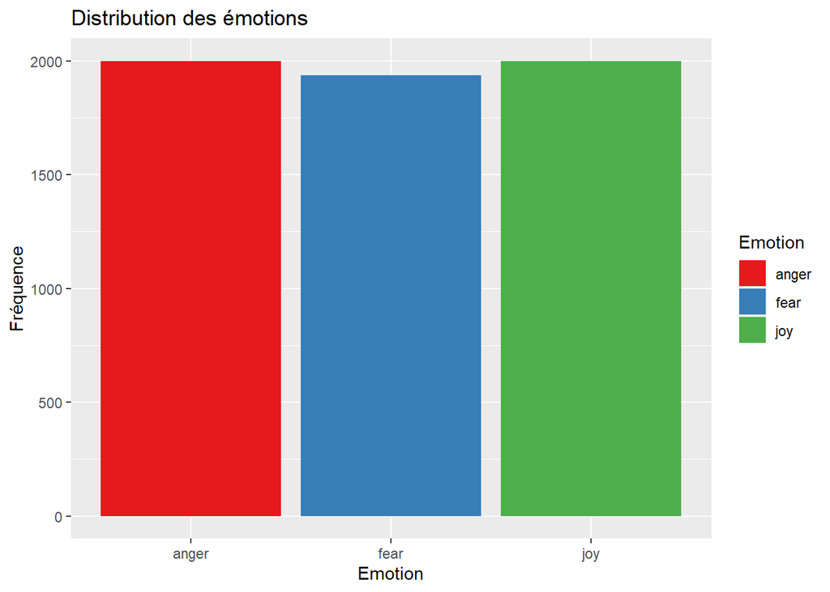

```r
# Distribution des classes
ggplot(df, aes(x=Emotion,fill = Emotion)) +
  geom_bar() +
  scale_fill_brewer(palette = "Set1") +
  xlab("Emotion") +
  ylab("Fréquence") +
  ggtitle("Distribution des émotions")
```

On regarde ensuite la longueur des chaînes de caractères et ajoute cette colonne à df. Affichage du tableau avec *kableExtra*

```r
# Ajout de la colonne TextLength
df$TextLength <- nchar(df$Comment)

head(df,6) %>%
  kbl(digits=3) %>%
  kable_styling(bootstrap_options = "striped", full_width = F, position = "center", latex_options = 'stripped') %>% scroll_box( height = "250px")
```

| Comment | Emotion | TextLength |
| --- | --- | --- |
| i seriously hate one subject to death but now i feel reluctant to drop it | fear | 73 |
| im so full of life i feel appalled | anger | 34 |
| i sit here to write i start to dig out my feelings and i think that i am afraid to accept the possibility that he might not make it | fear | 131 |
| ive been really angry with r and i feel like an idiot for trusting him in the first place | joy | 89 |
| i feel suspicious if there is no one outside like the rapture has happened or something | fear | 87 |
| i feel jealous becasue i wanted that kind of love the true connection between two souls and i wanted that | anger | 105 |

On va regarder les types de sentiments en fonction de la distribution de la longueur des textes.

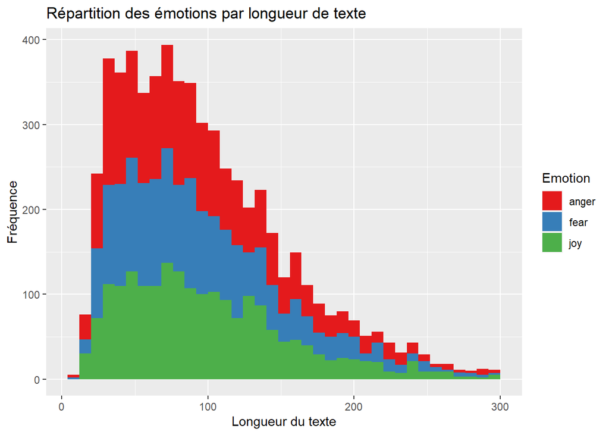

```r
# Distribution de la longueur des textes
ggplot(df, aes(x=TextLength,fill=Emotion)) +
  geom_histogram(binwidth = 8, position = "stack") +
  scale_fill_brewer(palette = "Set1") +
  xlab("Longueur du texte") +
  ylab("Fréquence") +
  ggtitle("Répartition des émotions par longueur de texte")
```

Cette dernière est assez uniforme.

### 3 Prétraitement des données

#### 3.1 Nettoyage les données textuelles en supprimant les caractères spéciaux, les chiffres et les mots vides

On va d’abord nétoyer nos données en supprimant la ponctuation, les chiffres, les mots vides, les espaces superflus

```r
# On enlève la colonne TextLength qui n'est plus utile ici
df_net_tok_stem <-df %>% select(-TextLength)
# Fonction pour nettoyer un texte
clean_text <- function(text) {
    text_corrige <- tolower(text)                                       # Convertir en minuscules
    text_corrige  <- removePunctuation(text_corrige )                   # Supprimer la ponctuation
    text_corrige  <- removeNumbers(text_corrige )                       # Supprimer les chiffres
    text_corrige  <- removeWords(text_corrige , stopwords("english"))   # Supprimer les mots vides
    text_corrige  <- stripWhitespace(text_corrige )                     # Supprimer les espaces superflus
    return(text_corrige)
  }
# Application de la fonction de nettoyage
df_net_tok_stem$Comment <- sapply(df_net_tok_stem$Comment, clean_text)
head(df_net_tok_stem,6) %>%
  kbl(digits=3) %>%
  kable_styling(bootstrap_options = "striped", full_width = F, position = "center", latex_options = 'stripped') %>%
  scroll_box(height = "250px")
```

| Comment | Emotion |
| --- | --- |
| seriously hate one subject death now feel reluctant drop | fear |
| im full life feel appalled | anger |
| sit write start dig feelings think afraid accept possibility might make | fear |
| ive really angry r feel like idiot trusting first place | joy |
| feel suspicious one outside like rapture happened something | fear |
| feel jealous becasue wanted kind love true connection two souls wanted | anger |

On va pouvoir maintenant appliquer la tokenization et le stemming avec la fonction tokenize_word_stems. Cette fonction tokenise et applique du stemming du package snowballC selon la doc.

```r
# Appliquer la tokenization et le stemming avec la fonction tokenize_word_stems
df_net_tok_stem$Comment<- sapply(df_net_tok_stem$Comment, function(phrase){
    tokenize_word_stems(phrase,language = "english")
  })

# On met des espaces entre les mots au lieu de ','
df_net_tok_stem$Comment <- sapply(df_net_tok_stem$Comment, paste, collapse = " ")

# Utilisez kable pour afficher
head(df_net_tok_stem,6) %>%
    kbl(digits=3) %>%
    kable_styling(bootstrap_options = "striped", full_width = F, position = "center", latex_options = 'stripped') %>%
    scroll_box(height = "250px")
```

| Comment | Emotion |
| --- | --- |
| serious hate one subject death now feel reluct drop | fear |
| im full life feel appal | anger |
| sit write start dig feel think afraid accept possibl might make | fear |
| ive realli angri r feel like idiot trust first place | joy |
| feel suspici one outsid like raptur happen someth | fear |
| feel jealous becasu want kind love true connect two soul want | anger |

On va faire un wordcloud pour voir les mots les plus fréquents par Emotion.

On calcule la fréquence de chaque mots par émotion.

```r
# Calcule de la fréquence de chaque mots par émotion
word_freq_emotion <- df_net_tok_stem %>%
  unnest_tokens(word, Comment)%>%
  count(Emotion, word, sort = TRUE)

head(word_freq_emotion,6)%>%
    kbl(digits=3) %>%
    kable_styling(bootstrap_options = "striped", full_width = F, position = "center", latex_options = 'stripped')
```

| Emotion | word | n |
| --- | --- | --- |
| joy | feel | 2112 |
| anger | feel | 2096 |
| fear | feel | 2025 |
| joy | like | 387 |
| anger | like | 362 |
| fear | im | 322 |

Voici la fonction pour les wordclouds.

```r
# Fonction pour créer un word cloud pour une émotion spécifique
generate_wordcloud_for_emotion <- function(emotion) {

  # Filtrer les mots par émotion spécifique
  word_freq <- filter(word_freq_emotion, Emotion == emotion)
  # Créer le word cloud
  wordcloud(words = word_freq$word, freq = word_freq$n, min.freq = 1,
            max.words = 200, random.order = FALSE,scale = c(5, 0.5), colors = brewer.pal(8, "Dark2"))
    # Ajoute un titre pour le nuage de mots avec l'émotion correspondante
  title(paste("Word cloud for emotion:", emotion))
}
```

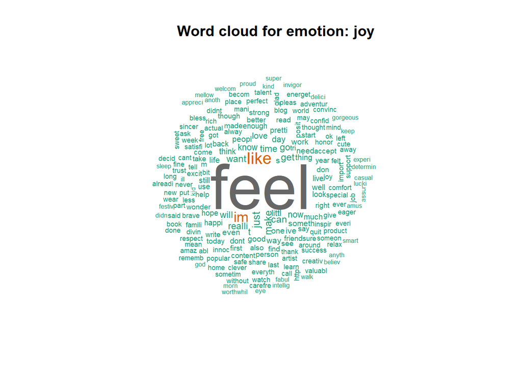

```r
generate_wordcloud_for_emotion('joy')
```

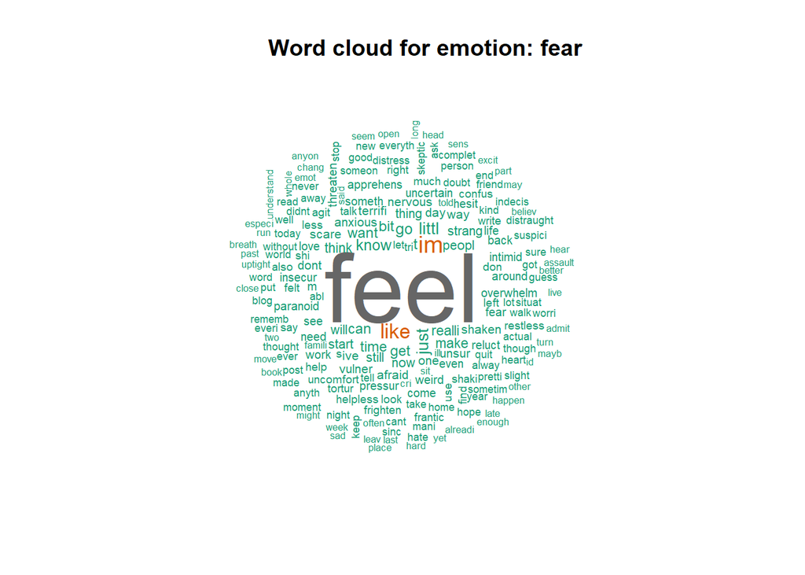

```r
generate_wordcloud_for_emotion('fear')
```

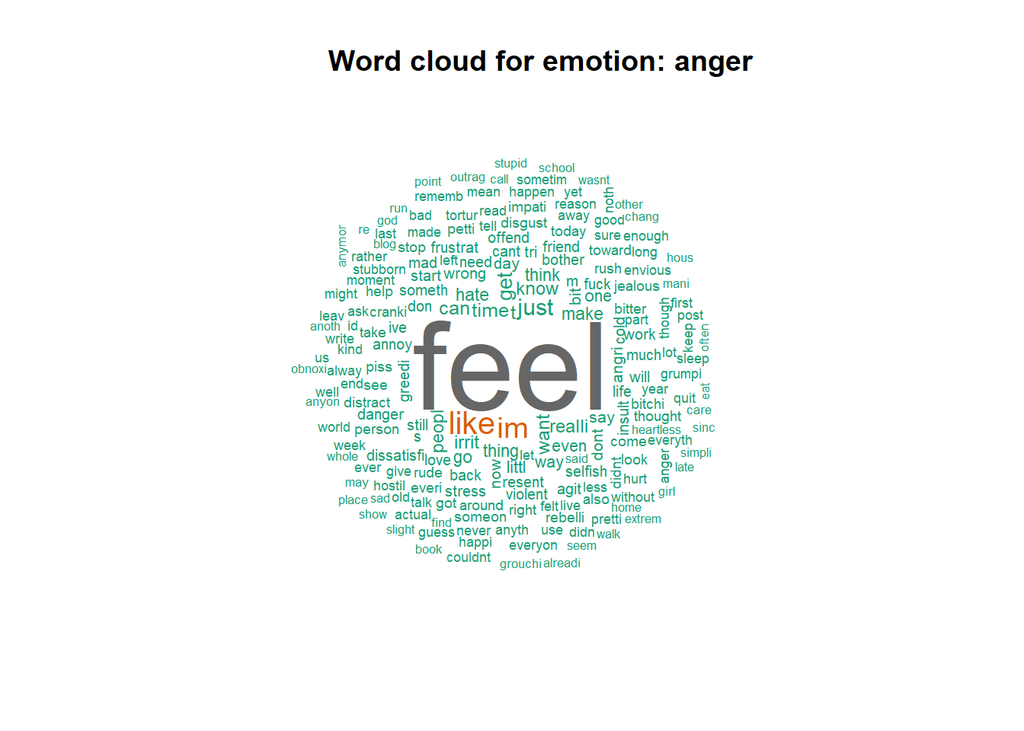

```r
generate_wordcloud_for_emotion('anger')
```

On observe ici que les résultats sont trop proche. On va utiliser une version log.

```r
# Mise à jour de la fonction pour utiliser la fréquence logarithmique
generate_wordcloud_for_emotion_2 <- function(emotion) {
  # Filtre les mots par émotion spécifique
  word_freq <- filter(word_freq_emotion, Emotion == emotion) %>%
    # Calculer le log des fréquences
  mutate(log_n = log(1+n))
  # Créer le word cloud en utilisant les fréquences logarithmiques
  wordcloud(words = word_freq$word, freq = word_freq$log_n, min.freq = 0,
            max.words = 200, random.order = FALSE,scale = c(1, 0.5), colors = brewer.pal(8, "Dark2"),rot.per = 0.35)

}
```

Pour la joie.

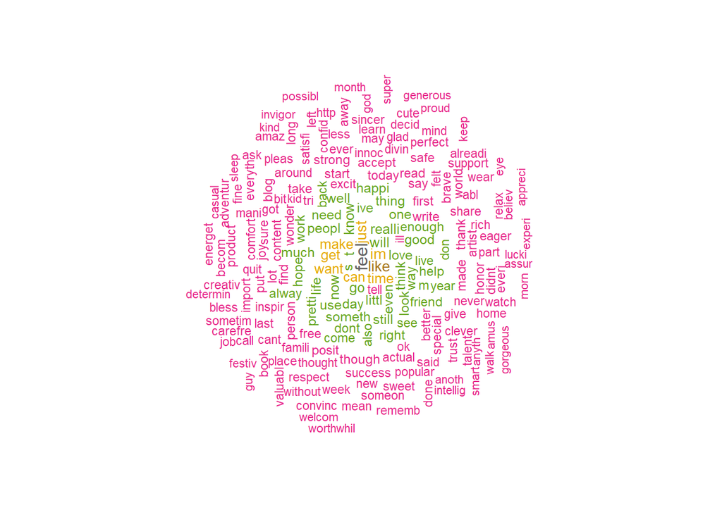

```r
generate_wordcloud_for_emotion_2('joy')
```

Pour la peur.

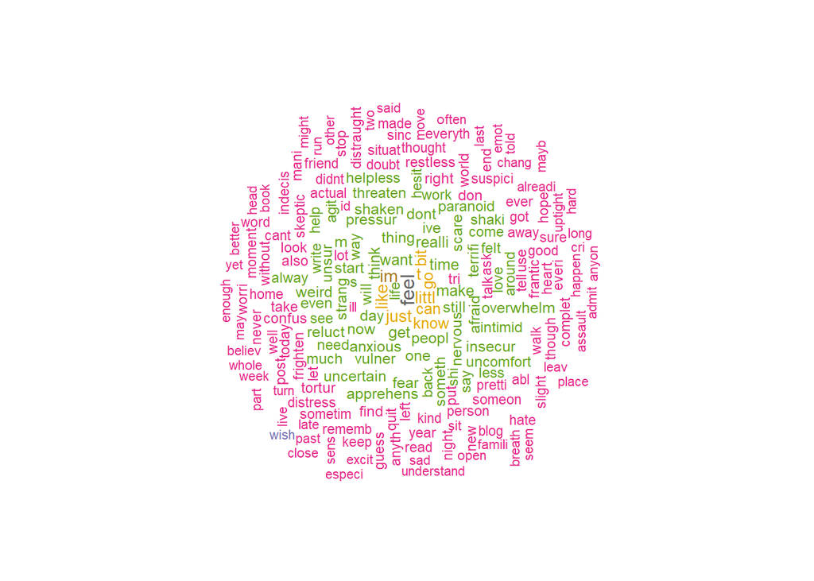

```r
generate_wordcloud_for_emotion_2('fear')
```

Pour la colère.

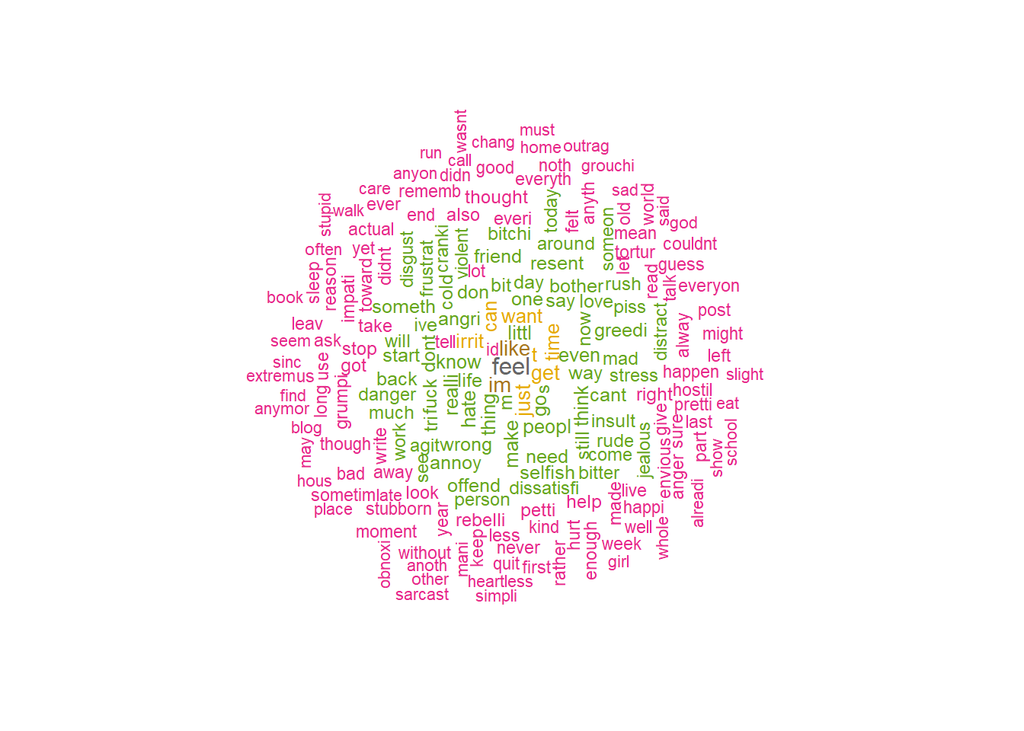

```r
generate_wordcloud_for_emotion_2('anger')
```

#### 3.2 TF-IDF

Maintenant qu’on a observé les mots les plus fréquents nous allons procéder à une TF-IDF. Pour cela nous allons d’abord séparer notre jeu de données en données d’entraînement et de test avec caret.

##### 3.2.1 Séparation des données

On va utiliser caret pour créer nos données d’entraînement et de test.

```r
set.seed(123) # pour une reproduction cohérente des résultats
  Index <- createDataPartition(df_net_tok_stem$Emotion, p = .8, list = FALSE)
  train <- df_net_tok_stem[Index,]
  test <- df_net_tok_stem[-Index,]
```

##### 3.2.2 Calcul de la TF-IDF

On peut maintenant passer au calcul de la TF-IDF. On commence par les données d’entraînement.

```r
# TF-IDF
# Étape 1: Création d'un corpus
corpus_train <- VCorpus(VectorSource(train$Comment))
# Étape 2: Création d'une DTM et application de la TF-IDF
dtm_train <- DocumentTermMatrix(corpus_train, control = list(weighting = weightTfIdf))

# Sauvegarde du vocabulaire pour le jeu d'entraînement
dict_train <- Terms(dtm_train)

# Convertir en dataframe
tf_idf_train_dataframe <- as.data.frame(as.matrix(dtm_train))

head(tf_idf_train_dataframe,6) %>%
  select(c(1:5, (ncol(tf_idf_train_dataframe)-4):ncol(tf_idf_train_dataframe))) %>%
  kbl(digits=3) %>%
  kable_styling(bootstrap_options = "striped", full_width = F, position = "center", latex_options = 'stripped')
```

| aac | aaron | abandon | abbigail | abc | ziplin | zombi | zone | zonisamid | zumba |
| --- | --- | --- | --- | --- | --- | --- | --- | --- | --- |
| 0 | 0 | 0 | 0 | 0 | 0 | 0 | 0 | 0 | 0 |
| 0 | 0 | 0 | 0 | 0 | 0 | 0 | 0 | 0 | 0 |
| 0 | 0 | 0 | 0 | 0 | 0 | 0 | 0 | 0 | 0 |
| 0 | 0 | 0 | 0 | 0 | 0 | 0 | 0 | 0 | 0 |
| 0 | 0 | 0 | 0 | 0 | 0 | 0 | 0 | 0 | 0 |
| 0 | 0 | 0 | 0 | 0 | 0 | 0 | 0 | 0 | 0 |

On va faire de même pour les données de tests en prenant le dictionnaire dict_train comportant tout le vocabulaire d’entraînement.

```r
# TF-IDF
# Étape 1: Création d'un corpus
corpus_test <- VCorpus(VectorSource(test$Comment))
# Étape 2: Création d'une DTM et application de la TF-IDF
dtm_test <- DocumentTermMatrix(corpus_test, control = list(weighting = weightTfIdf, dictionary = dict_train))
```

[output not shown]

[output cut: 53 more lines]

[output not shown]

```r
# Convertir en dataframe
tf_idf_test_dataframe <- as.data.frame(as.matrix(dtm_test))

head(tf_idf_test_dataframe,6) %>%
  select(c(1:5, (ncol(tf_idf_test_dataframe)-4):ncol(tf_idf_test_dataframe))) %>%
  kbl(digits=3) %>%
  kable_styling(bootstrap_options = "striped", full_width = F, position = "center", latex_options = 'stripped')
```

| aac | aaron | abandon | abbigail | abc | ziplin | zombi | zone | zonisamid | zumba |
| --- | --- | --- | --- | --- | --- | --- | --- | --- | --- |
| 0 | 0 | 0 | 0 | 0 | 0 | 0 | 0 | 0 | 0 |
| 0 | 0 | 0 | 0 | 0 | 0 | 0 | 0 | 0 | 0 |
| 0 | 0 | 0 | 0 | 0 | 0 | 0 | 0 | 0 | 0 |
| 0 | 0 | 0 | 0 | 0 | 0 | 0 | 0 | 0 | 0 |
| 0 | 0 | 0 | 0 | 0 | 0 | 0 | 0 | 0 | 0 |
| 0 | 0 | 0 | 0 | 0 | 0 | 0 | 0 | 0 | 0 |

On a alors notre TF-IDF, on peut alors passer à l’entraînement du modèle.

### 4 Entraînement du modèle bayésien

#### 4.1 Divisez les données en un ensemble d’apprentissage et un ensemble de test

On séparare les variables catégorielles et numériques.

```r
# Séparation des variables catégorielles et numériques
X_train <- tf_idf_train_dataframe
X_test <- tf_idf_test_dataframe
y_train <- as.factor(train$Emotion)
y_test <- as.factor(test$Emotion)
```

On vérifie qu’on a bien le même nombre de lignes entre X et y (train et test).

```r
print(dim(X_train))
```

```
## [1] 4750 5508
```

```r
print(length(y_train))
```

```
## [1] 4750
```

```r
print(dim(X_test))
```

```
## [1] 1187 5508
```

```r
print(length(y_test))
```

```
## [1] 1187
```

On a bien le même nombre de lignes entre X et y (train et test).

#### 4.2 Utilisation du package e1071 R pour entraîner un classifieur bayésien naïf et entraînement de ce dernier sur l’ensemble d’apprentissage et réaliser des prédictions sur l’ensemble de test

On regarde si la distribution des classes est bien répartie.

```r
table(y_train)
```

```
## y_train
## anger  fear   joy
##  1600  1550  1600
```

```r
table(y_test)
```

```
## y_test
## anger  fear   joy
##   400   387   400
```

On constate que la répartion des classes est bien équilibrée.

On peut donc maintenant entraîner notre modèle.

```r
# Entraînement du modèle bayésien naïf
# model <- naiveBayes(X_train, y_train)
```

Prédiction sur les données d’entraînement.

```r
# Prédictions sur l'ensemble d'entraînement
# predictions_train <- predict(model, newdata = X_train)
```

Prédiction sur les données de test.

```r
# Prédiction sur l'ensemble de test
# predictions <- predict(model, newdata = X_test)
```

On sauvegarde tout ceci dans un fichier RDA car ces derniers prennent un peu de temps à s’executer.

```r
# Sauvegarder les variables dans un fichier .rda
# save(model, predictions_train, predictions, file = "model_predictions.Rda")
```

On charge le modèle.

```r
load("model_predictions.Rda")
```

### 5 Évaluation du modèle

On regarde l’accuracy d’entraînement.

```r
# Calcul de l'accuracy
accuracy_train <- sum(predictions_train == y_train) / length(y_train)
print(accuracy_train)
```

```
## [1] 0.32
```

Regardons la matrice de confusion pour mieux comprendre les résultats.

```r
# Évaluation du modèle
confusionMatrice <- table(as.factor(predictions), y_test)
confusionMatrice
```

```
##        y_test
##         anger fear joy
##   anger    66   35  68
##   fear    332  351 329
##   joy       2    1   3
```

```r
# Évaluation du modèle
confusionMatrix(predictions, y_test)
```

```
## Confusion Matrix and Statistics
##
##           Reference
## Prediction anger fear joy
##      anger    66   35  68
##      fear    332  351 329
##      joy       2    1   3
##
## Overall Statistics
##
##                Accuracy : 0.3538
##                  95% CI : (0.3266, 0.3818)
##     No Information Rate : 0.337
##     P-Value [Acc > NIR] : 0.1158
##
##                   Kappa : 0.0389
##
##  Mcnemar's Test P-Value : <2e-16
##
## Statistics by Class:
##
##                      Class: anger Class: fear Class: joy
## Sensitivity                0.1650      0.9070   0.007500
## Specificity                0.8691      0.1737   0.996188
## Pos Pred Value             0.3905      0.3468   0.500000
## Neg Pred Value             0.6719      0.7943   0.663844
## Prevalence                 0.3370      0.3260   0.336984
## Detection Rate             0.0556      0.2957   0.002527
## Detection Prevalence       0.1424      0.8526   0.005055
## Balanced Accuracy          0.5171      0.5404   0.501844
```

#### 5.1 Calcul de l’exactitude, la précision, le rappel et le score F1 (Accuracy, Precision, Recall, and F1-score)

Nous faisons cette fonction pour calculer la précision, le rappel et le score F1 en fonction des classes. On calcule également l’accuracy global du modèle.

```r
calculate_metrics <- function(confusionMatrix) {
    # Extracting the number of classes
    n <- nrow(confusionMatrix)
    # Initializing vectors to store metrics for each class
    precision <- numeric(n)
    recall <- numeric(n)
    f1_score <- numeric(n)
    # Calculating metrics for each class
    for (i in 1:n) {
      TP <- confusionMatrix[i, i]
      FP <- sum(confusionMatrix[i, ]) - TP
      FN <- sum(confusionMatrix[, i]) - TP
      precision[i] <- TP / (TP + FP)
      recall[i] <- TP / (TP + FN)
      f1_score[i] <- ifelse((precision[i] + recall[i]) > 0, (2 * precision[i] * recall[i]) / (precision[i] + recall[i]), 0)
    }
    # Calculating the global accuracy
    global_accuracy <- sum(diag(confusionMatrix)) / sum(confusionMatrix)
    # Returning a list containing the metrics
    metrics <-list(
      "Global Accuracy" = global_accuracy,
      "Precision" = precision,
      "Recall" = recall,
      "F1 Score" = f1_score
    )
    # Creating a data frame to display precision, recall, and F1 score for each class
    metrics_df <- data.frame(
    Class = rownames(confusionMatrix),
    Precision = metrics$Precision,
    Recall = metrics$Recall,
    `F1 Score` = metrics$`F1 Score`)
    # Ajout d'une colonne "Global Accuracy" avec des NA
    metrics_df$`Global Accuracy` <- NA
    metrics_df
    # Calcul des moyennes pour les autres métriques
    average_metrics <- c(
    "Average",
    mean(metrics$Precision),
    mean(metrics$Recall),
    mean(metrics$`F1 Score`),
    metrics$`Global Accuracy`  # Ajouter l'accuracy globale pour la ligne "Average"
    )
    # Ajout de la ligne des moyennes au data frame
    metrics_df <- rbind(metrics_df, average_metrics)
    return (metrics_df)
  }
```

```r
#  Évaluation du modèle
metrics_df <- calculate_metrics(confusionMatrice)

# Affichage
metrics_df%>%
    kbl(digits=3) %>%
    kable_styling(bootstrap_options = "striped", full_width = F, position = "center", latex_options = 'stripped')
```

| Class | Precision | Recall | F1.Score | Global Accuracy |
| --- | --- | --- | --- | --- |
| anger | 0.390532544378698 | 0.165 | 0.231985940246046 | NA |
| fear | 0.346837944664032 | 0.906976744186046 | 0.501786990707648 | NA |
| joy | 0.5 | 0.0075 | 0.0147783251231527 | NA |
| Average | 0.41245682968091 | 0.359825581395349 | 0.249517085358949 | 0.353833192923336 |

Les résultats montrent des performances variables du modèle sur différentes classes d’émotion. La précision pour la peur est notable à 34.68% avec un rappel impressionnant de 90.69%, indiquant une forte capacité à identifier cette émotion. Cependant, la performance sur la joie est faible, avec une précision de 50% mais un rappel extrêmement bas à 0.75%, soulignant une difficulté à détecter cette émotion. L’anger a une précision de 39.05% et un rappel de 16.5%. La précision moyenne du modèle est de 41.25%, avec un rappel moyen de 35.98% et un score F1 moyen de 24.95%, tandis que l’accuracy globale atteint 35.38%. Tout ceci indique que le modèle bayésien naïf n’est clairement pas adapté ici car les résultats ne sont pas fiables.

### 6 Amélioration et optimisation

#### 6.1 Normalisation de la TF-IDF

```r
# Fonction pour normaliser les lignes d'un dataframe
normalize <- function(x) {
  return (x / sqrt(sum(x^2)))
}

# Appliquer la normalisation sur les dataframes TF-IDF

tf_idf_train_dataframe_norm <- as.data.frame(lapply(tf_idf_train_dataframe, function(x) x / sqrt(sum(x^2))))

tf_idf_test_dataframe_norm <- as.data.frame(lapply(tf_idf_test_dataframe, function(x) x / sqrt(sum(x^2))))
```

On séparare les variables catégorielles et numériques.

```r
# Séparation des variables catégorielles et numériques
X_train_norm <- tf_idf_train_dataframe_norm
X_test_norm <- tf_idf_test_dataframe_norm
y_train_norm <- as.factor(train$Emotion)
y_test_norm <- as.factor(test$Emotion)
```

On vérifie qu’on a bien le même nombre de lignes entre X et y (train et test).

```r
print(dim(X_train_norm))
```

```
## [1] 4750 5508
```

```r
print(length(y_train_norm))
```

```
## [1] 4750
```

```r
print(dim(X_test_norm))
```

```
## [1] 1187 5508
```

```r
print(length(y_test_norm))
```

```
## [1] 1187
```

On a bien le même nombre de lignes entre X et y (train et test).

On regarde si la distribution des classes est bien répartie.

```r
table(y_train_norm)
```

```
## y_train_norm
## anger  fear   joy
##  1600  1550  1600
```

```r
table(y_test_norm)
```

```
## y_test_norm
## anger  fear   joy
##   400   387   400
```

On constate que la répartion des classes est bien équilibrée.

On peut donc maintenant entraîner notre modèle. On le sauvegarde en fichier RDA car ce dernier prend un peu de temps à s’entraîner.

```r
# Entraînement du modèle bayésien naïf
# model_norm <- naiveBayes(X_train_norm, y_train_norm)
```

Prédiction sur les données d’entraînement.

```r
# Prédictions sur l'ensemble d'entraînement
# predictions_train_norm <- predict(model_norm, newdata = X_train_norm)
```

Prédiction sur les données de test.

```r
# Prédiction sur l'ensemble de test
# predictions_norm <- predict(model_norm, newdata = X_test_norm)
```

On sauvegarde tout ceci dans un fichier RDA car ces derniers prennent un peu de temps à s’executer.

```r
# Sauvegarder les variables dans un fichier .rda
# save(model_norm, predictions_train_norm, predictions_norm, file = "model_predictions_norm.Rda")
```

On charge le modèle.

```r
load("model_predictions_norm.Rda")
```

On regarde l’accuracy d’entraînement.

```r
# Calcul de l'accuracy
accuracy_train_norm <- sum(predictions_train_norm == y_train_norm) / length(y_train_norm)
print(accuracy_train_norm)
```

```
## [1] 0.3189474
```

Regardons la matrice de confusion pour mieux comprendre les résultats.

```r
# Évaluation du modèle
confusionMatrice_norm <- table(as.factor(predictions_norm), y_test_norm)
confusionMatrice_norm
```

```
##        y_test_norm
##         anger fear joy
##   anger   149  177 136
##   fear    194  156 210
##   joy      57   54  54
```

```r
# Évaluation du modèle
confusionMatrix(predictions, y_test)
```

```
## Confusion Matrix and Statistics
##
##           Reference
## Prediction anger fear joy
##      anger    66   35  68
##      fear    332  351 329
##      joy       2    1   3
##
## Overall Statistics
##
##                Accuracy : 0.3538
##                  95% CI : (0.3266, 0.3818)
##     No Information Rate : 0.337
##     P-Value [Acc > NIR] : 0.1158
##
##                   Kappa : 0.0389
##
##  Mcnemar's Test P-Value : <2e-16
##
## Statistics by Class:
##
##                      Class: anger Class: fear Class: joy
## Sensitivity                0.1650      0.9070   0.007500
## Specificity                0.8691      0.1737   0.996188
## Pos Pred Value             0.3905      0.3468   0.500000
## Neg Pred Value             0.6719      0.7943   0.663844
## Prevalence                 0.3370      0.3260   0.336984
## Detection Rate             0.0556      0.2957   0.002527
## Detection Prevalence       0.1424      0.8526   0.005055
## Balanced Accuracy          0.5171      0.5404   0.501844
```

On calcule la précision, le rappel et le score F1 en fonction des classes et également l’accuracy global du modèle.

```r
#  Évaluation du modèle
metrics_df_norm <- calculate_metrics(confusionMatrice_norm)

# Affichage
metrics_df_norm %>%
    kbl(digits=3) %>%
    kable_styling(bootstrap_options = "striped", full_width = F, position = "center", latex_options = 'stripped')
```

| Class | Precision | Recall | F1.Score | Global Accuracy |
| --- | --- | --- | --- | --- |
| anger | 0.322510822510823 | 0.3725 | 0.345707656612529 | NA |
| fear | 0.278571428571429 | 0.403100775193798 | 0.329461457233369 | NA |
| joy | 0.327272727272727 | 0.135 | 0.191150442477876 | NA |
| Average | 0.309451659451659 | 0.303533591731266 | 0.288773185441258 | 0.302443133951137 |

#### 6.2 Validation croisée

```r
# set.seed(123)

# # Créer des indices pour la validation croisée k-fold
# k <- 10
# folds <- createFolds(df_net_tok_stem$Emotion, k = k, list = TRUE, returnTrain = TRUE)

# # Initialiser une liste pour stocker les résultats
# accuracy_list <- vector("numeric", length = k)

# for(i in seq_along(folds)) {
#   # Séparation du jeu de données en train et test pour le pli
#   train_indices <- folds[[i]]
#   test_indices <- setdiff(seq_len(nrow(df_net_tok_stem)), train_indices)

#   train <- df_net_tok_stem[train_indices, ]
#   test <- df_net_tok_stem[test_indices, ]

#   # TF-IDF pour les données d'entraînement
#   corpus_train <- VCorpus(VectorSource(train$Comment))
#   dtm_train <- DocumentTermMatrix(corpus_train, control = list(weighting = weightTfIdf))
#   tf_idf_train <- as.data.frame(as.matrix(dtm_train))

#   # Utiliser le même vocabulaire pour les données de test
#   corpus_test <- VCorpus(VectorSource(test$Comment))
#   dtm_test <- DocumentTermMatrix(corpus_test, control = list(weighting = weightTfIdf, dictionary = Terms(dtm_train)))
#   tf_idf_test <- as.data.frame(as.matrix(dtm_test))


#   # Séparation des données pour l'entraînement
#   X_train <- tf_idf_train
#   X_test <- tf_idf_test
#   y_train <- as.factor(train$Emotion)
#   y_test <- as.factor(test$Emotion)


#   # Entraînement du modèle bayésien naïf
#   model_nb <- naiveBayes(X_train, y_train)

#   # Prédiction sur l'ensemble de test
#   predictions <- predict(model_nb, newdata = X_test)

#   accuracy <- sum(predictions == y_test) / length(y_test)
#   accuracy_list[i] <- accuracy
# }
# mean_accuracy <- mean(accuracy_list)
```

```r
# Sauvegarder les variables dans un fichier .rda
# save(accuracy_list, mean_accuracy, file = "model_kfold.Rda")
```

```r
load("model_kfold.Rda")
```

```r
print(accuracy_list)
```

```
##  [1] 0.3350168 0.3552189 0.3350168 0.3484848 0.3484848 0.3726813 0.3541315
##  [8] 0.3524452 0.3636364 0.3434343
```

```r
# Calculer la précision moyenne sur tous les plis
print(mean_accuracy)
```

```
## [1] 0.3508551
```

Encore une fois, le modèle naiveBayes n’est pas adéquat ici.

### 7 Conclusion

Le modèle bayésien naïf, avec une précision moyenne globale autour de 35%, ne fournit pas une fiabilité suffisante pour la classification des émotions dans le texte. Les performances variables entre différentes émotions, particulièrement les difficultés avec la joie, suggèrent que ce modèle est inadéquat pour capturer la complexité des données émotionnelles. On pourrait donc envisager d’autres modèles plus sophistiqués comme les réseaux de neurones pour palier à ce problème.